# Arizona Data Comparison

Joe Champion, Thea Sukianto

August 24, 2019

## Setup

### Helper Functions/Libraries

```r
source('R/data_analysis.R')
library(dplyr)
library(ggplot2)
```

### Load Correct (manually cleaned) Arizona Data

- Renames ‘collar’, ‘date’, ‘distancetr’, and ‘RATE’ columns to ‘GPS’, ‘Date’, ‘Distance’, and ‘Rate’ respectively so names match with candidate data

```r
df_correct <- read.csv('inst/extdata/correct.csv', stringsAsFactors = F) %>%
  dplyr::rename(GPS = collar) %>%
  dplyr::rename(Date = date) %>%
  dplyr::rename(Distance = distancetr) %>%
  dplyr::rename(Rate = RATE) %>%
  dplyr::mutate(Date = as.Date(Date))
```

### Load Candidate (cleaned by animaltracker) Arizona Data

```r
df_candidate <- read.csv('inst/extdata/candidate.csv', stringsAsFactors = F) %>%
  dplyr::mutate(Date = as.Date(Date))
```

## Calculate Summary Statistics

```r
dfs <- compare_summarise_data(df_correct,
                       df_candidate,
                       'inst/extdata/processed/gps_arizona.csv',
                       'inst/extdata/processed/date_arizona.csv'
                       )
```

### Summary by GPS Collar

- **Close match** between latitude, longitude, course
- Candidate has **less rows**
- **Underestimates** distance, rate **(less variable)**
- **Overestimates** elevation **(more variable)**

```r
summary(dfs$GPS)
```

```
##       GPS              n.x            n.y           nDiff
##  Min.   : 79.00   Min.   :3599   Min.   :3532   Min.   : 67.0
##  1st Qu.: 83.50   1st Qu.:6406   1st Qu.:6278   1st Qu.: 91.5
##  Median : 88.00   Median :6914   Median :6820   Median :120.0
##  Mean   : 89.05   Mean   :6844   Mean   :6715   Mean   :128.7
##  3rd Qu.: 94.50   3rd Qu.:7476   3rd Qu.:7374   3rd Qu.:169.5
##  Max.   :102.00   Max.   :8056   Max.   :7870   Max.   :213.0
##    meanLat.x       meanLat.y      meanLatDiff            sdLat.x
##  Min.   :32.05   Min.   :32.05   Min.   :-1.106e-05   Min.   :0.002174
##  1st Qu.:32.05   1st Qu.:32.05   1st Qu.: 2.595e-05   1st Qu.:0.003491
##  Median :32.05   Median :32.05   Median : 3.215e-05   Median :0.004421
##  Mean   :32.05   Mean   :32.05   Mean   : 3.329e-05   Mean   :0.004071
##  3rd Qu.:32.05   3rd Qu.:32.05   3rd Qu.: 3.765e-05   3rd Qu.:0.004734
##  Max.   :32.06   Max.   :32.06   Max.   : 7.255e-05   Max.   :0.005407
##     sdLat.y           sdLatDiff          meanLong.x       meanLong.y
##  Min.   :0.002140   Min.   :0.003051   Min.   :-109.4   Min.   :-109.4
##  1st Qu.:0.003540   1st Qu.:0.004972   1st Qu.:-109.4   1st Qu.:-109.4
##  Median :0.004451   Median :0.006282   Median :-109.4   Median :-109.4
##  Mean   :0.004128   Mean   :0.005798   Mean   :-109.4   Mean   :-109.4
##  3rd Qu.:0.004807   3rd Qu.:0.006747   3rd Qu.:-109.4   3rd Qu.:-109.4
##  Max.   :0.005436   Max.   :0.007667   Max.   :-109.3   Max.   :-109.3
##   meanLongDiff           sdLong.x           sdLong.y
##  Min.   :-3.690e-05   Min.   :0.005252   Min.   :0.005248
##  1st Qu.: 8.396e-05   1st Qu.:0.018245   1st Qu.:0.018251
##  Median : 1.164e-04   Median :0.021180   Median :0.021179
##  Mean   : 1.205e-04   Mean   :0.019545   Mean   :0.019559
##  3rd Qu.: 1.694e-04   3rd Qu.:0.021998   3rd Qu.:0.022009
##  Max.   : 2.910e-04   Max.   :0.022916   Max.   :0.022975
##    sdLongDiff         meanDist.x      meanDist.y     meanDistDiff
##  Min.   :0.007425   Min.   :49.55   Min.   :46.03   Min.   :3.486
##  1st Qu.:0.025806   1st Qu.:56.60   1st Qu.:50.97   1st Qu.:4.462
##  Median :0.029952   Median :61.76   Median :55.87   Median :5.769
##  Mean   :0.027651   Mean   :60.53   Mean   :54.56   Mean   :5.969
##  3rd Qu.:0.031118   3rd Qu.:63.91   3rd Qu.:57.89   3rd Qu.:6.981
##  Max.   :0.032450   Max.   :69.72   Max.   :60.41   Max.   :9.810
##     sdDist.x        sdDist.y        sdDistDiff     meanCourse.x
##  Min.   :100.7   Min.   : 81.52   Min.   :129.5   Min.   :173.2
##  1st Qu.:116.6   1st Qu.: 90.33   1st Qu.:148.7   1st Qu.:174.3
##  Median :123.7   Median : 94.18   Median :157.6   Median :175.1
##  Mean   :125.9   Mean   : 92.93   Mean   :156.6   Mean   :175.7
```

[output cut: 22 more lines]

[output not shown]

#### Number of Observations

- Candidate has approximately 90-170 **less rows** (out of ~6400 - 7500 per GPS collar)

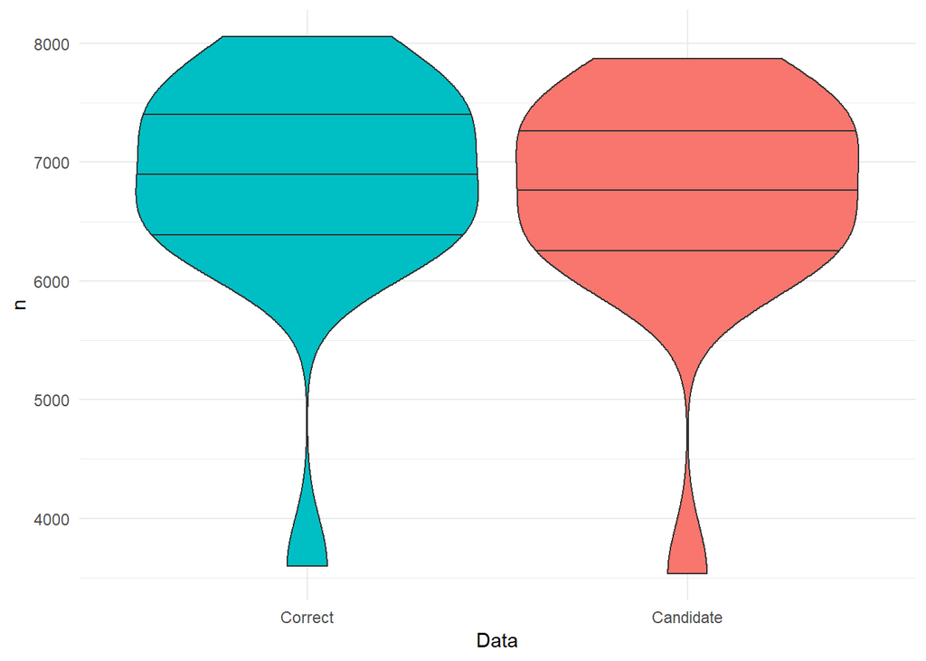

```r
violin_compare(dfs$GPS, GPS, "n", "inst/extdata/processed/n_GPS_arizona.png")
```

#### Mean Latitude

- Differences are on the order of **~1x10^-5** on average

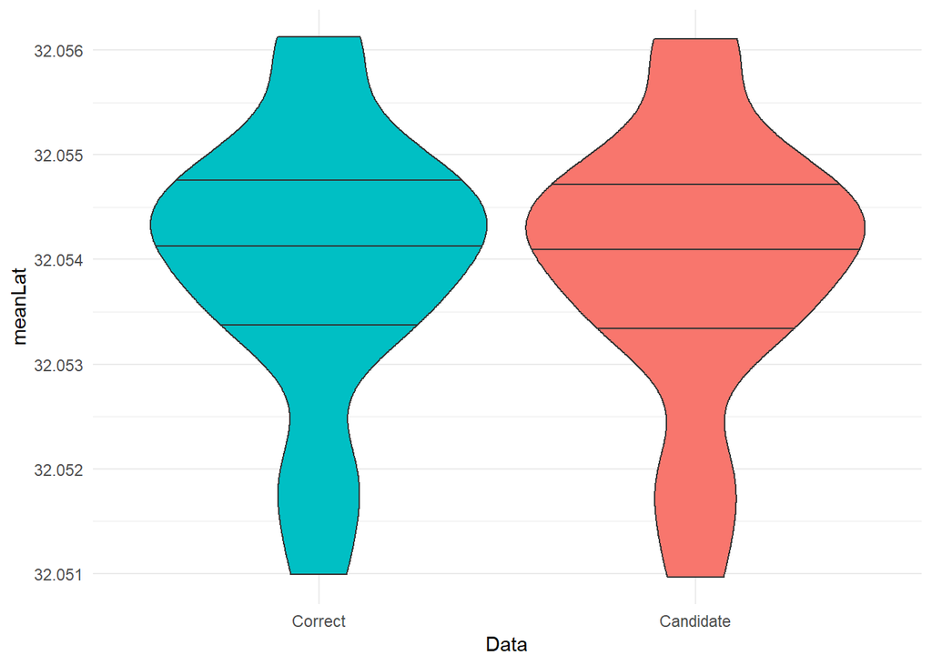

```r
violin_compare(dfs$GPS, GPS, "meanLat", "inst/extdata/processed/meanLat_GPS_arizona.png")
```

#### Mean Longitude

- Differences are on the order of **~1x10^-5 - 1x10^-4** on average

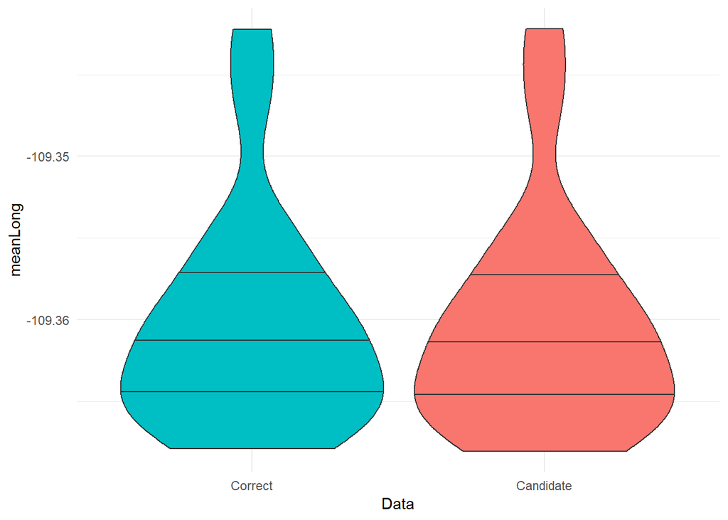

```r
violin_compare(dfs$GPS, GPS, "meanLong", "inst/extdata/processed/meanLong_GPS_arizona.png")
```

#### Mean Distance

- Candidate **underestimates** distance on average by ~4.5 - 7

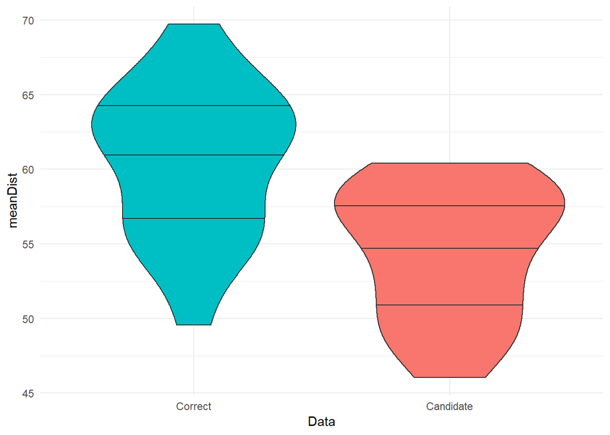

```r
violin_compare(dfs$GPS, GPS, "meanDist", "inst/extdata/processed/meanDist_GPS_arizona.png")
```

#### Mean Course

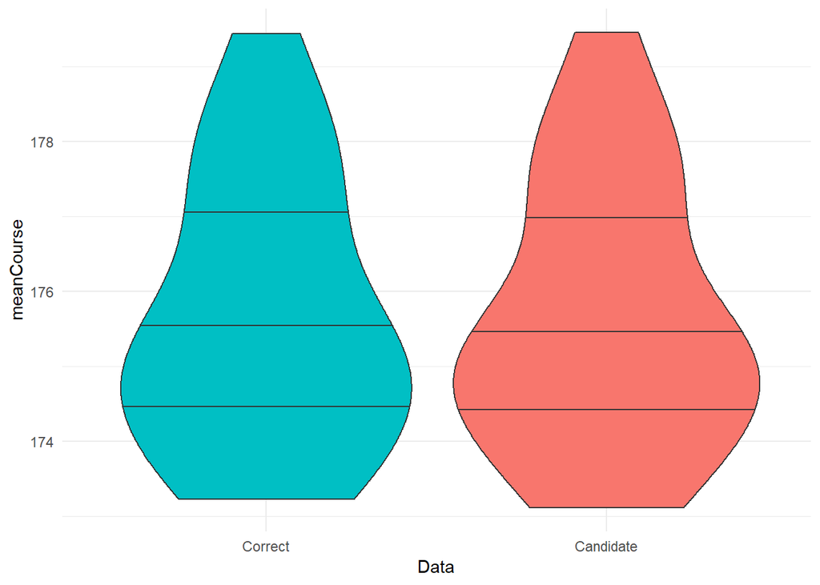

```r
violin_compare(dfs$GPS, GPS, "meanCourse", "inst/extdata/processed/meanCourse_GPS_arizona.png")
```

#### Mean Rate

- Candidate **underestimates** rate on average by ~0.20 - 0.28

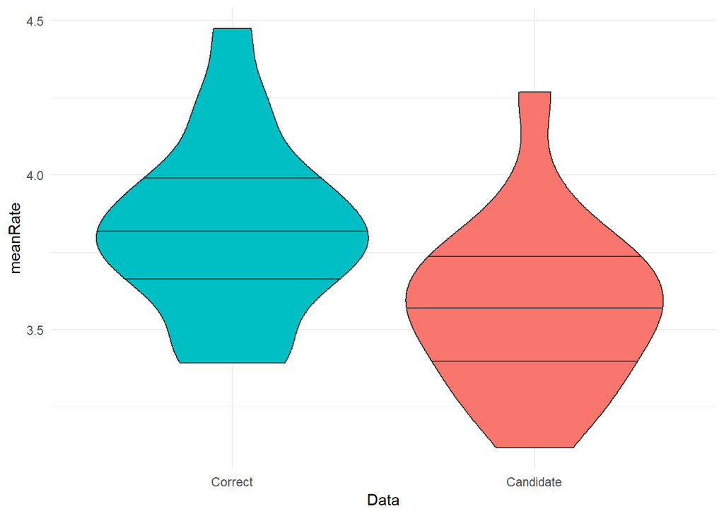

```r
violin_compare(dfs$GPS, GPS, "meanRate", "inst/extdata/processed/meanRate_GPS_arizona.png")
```

#### Mean Elevation

- Candidate **overestimates** elevation on average by ~19 - 26

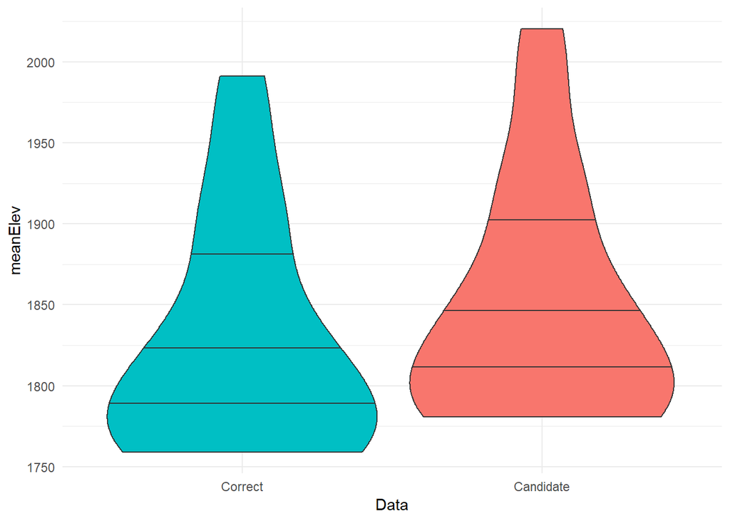

```r
violin_compare(dfs$GPS, GPS, "meanElev", "inst/extdata/processed/meanElev_GPS_arizona.png")
```

### Summary by Date

```r
summary(dfs$Date)
```

```
##       Date                 n.x            n.y           nDiff
##  Min.   :2018-03-05   Min.   :1302   Min.   :1324   Min.   :-91.00
##  1st Qu.:2018-03-25   1st Qu.:1502   1st Qu.:1484   1st Qu.: -1.00
##  Median :2018-04-15   Median :1587   Median :1554   Median : 38.00
##  Mean   :2018-04-15   Mean   :1567   Mean   :1537   Mean   : 29.47
##  3rd Qu.:2018-05-05   3rd Qu.:1625   3rd Qu.:1603   3rd Qu.: 60.00
##  Max.   :2018-05-26   Max.   :1744   Max.   :1785   Max.   :140.00
##    meanLat.x       meanLat.y      meanLatDiff            sdLat.x
##  Min.   :32.05   Min.   :32.05   Min.   :-2.228e-03   Min.   :0.001182
##  1st Qu.:32.05   1st Qu.:32.05   1st Qu.:-2.611e-04   1st Qu.:0.002635
##  Median :32.05   Median :32.05   Median : 2.900e-05   Median :0.003493
##  Mean   :32.05   Mean   :32.05   Mean   : 3.017e-05   Mean   :0.003530
##  3rd Qu.:32.06   3rd Qu.:32.06   3rd Qu.: 2.591e-04   3rd Qu.:0.004306
##  Max.   :32.06   Max.   :32.06   Max.   : 3.727e-03   Max.   :0.006454
##     sdLat.y           sdLatDiff          meanLong.x       meanLong.y
##  Min.   :0.001119   Min.   :0.001628   Min.   :-109.4   Min.   :-109.4
##  1st Qu.:0.002572   1st Qu.:0.003700   1st Qu.:-109.4   1st Qu.:-109.4
##  Median :0.003662   Median :0.005011   Median :-109.4   Median :-109.4
##  Mean   :0.003586   Mean   :0.005045   Mean   :-109.4   Mean   :-109.4
##  3rd Qu.:0.004288   3rd Qu.:0.006078   3rd Qu.:-109.3   3rd Qu.:-109.3
##  Max.   :0.008026   Max.   :0.009263   Max.   :-109.3   Max.   :-109.3
##   meanLongDiff           sdLong.x           sdLong.y
##  Min.   :-2.387e-03   Min.   :0.002627   Min.   :0.002195
##  1st Qu.:-2.193e-04   1st Qu.:0.005090   1st Qu.:0.005098
##  Median : 5.879e-05   Median :0.006815   Median :0.007097
##  Mean   : 9.274e-05   Mean   :0.008869   Mean   :0.008882
##  3rd Qu.: 4.961e-04   3rd Qu.:0.012912   3rd Qu.:0.012857
##  Max.   : 1.808e-03   Max.   :0.017869   Max.   :0.017808
##    sdLongDiff         meanDist.x      meanDist.y     meanDistDiff
##  Min.   :0.003720   Min.   :50.41   Min.   :45.24   Min.   :-4.112
##  1st Qu.:0.007264   1st Qu.:56.42   1st Qu.:50.71   1st Qu.: 3.274
##  Median :0.009913   Median :59.80   Median :54.07   Median : 5.500
##  Mean   :0.012560   Mean   :60.45   Mean   :54.53   Mean   : 5.922
##  3rd Qu.:0.018072   3rd Qu.:63.82   3rd Qu.:58.22   3rd Qu.: 8.641
##  Max.   :0.025040   Max.   :73.08   Max.   :66.33   Max.   :16.161
##     sdDist.x         sdDist.y        sdDistDiff     meanCourse.x
##  Min.   : 86.05   Min.   : 71.67   Min.   :118.9   Min.   :169.2
##  1st Qu.:109.27   1st Qu.: 86.01   1st Qu.:143.7   1st Qu.:173.8
##  Median :120.11   Median : 91.93   Median :151.9   Median :175.6
##  Mean   :124.06   Mean   : 92.41   Mean   :155.3   Mean   :175.7
```

[output cut: 22 more lines]

```
##  Max.   :8.621   Max.   :8.170   Max.   :11.431   Max.   :2049
##    meanElev.y    meanElevDiff        sdElev.x         sdElev.y
##  Min.   :1646   Min.   :-69.089   Min.   : 17.37   Min.   : 18.91
##  1st Qu.:1690   1st Qu.:-33.998   1st Qu.: 69.82   1st Qu.: 84.08
##  Median :1842   Median :-23.621   Median : 96.35   Median :101.55
##  Mean   :1845   Mean   :-22.694   Mean   : 95.03   Mean   :100.78
##  3rd Qu.:1976   3rd Qu.: -9.654   3rd Qu.:118.89   3rd Qu.:121.92
##  Max.   :2086   Max.   : 11.641   Max.   :172.22   Max.   :165.02
##    sdElevDiff
##  Min.   : 25.68
##  1st Qu.:105.62
##  Median :142.23
##  Mean   :138.74
##  3rd Qu.:169.87
##  Max.   :229.12
```

#### Number of Observations

- Candidate tends to have **less rows** per date (difference between correct and candidate: ~ -1 - 60)

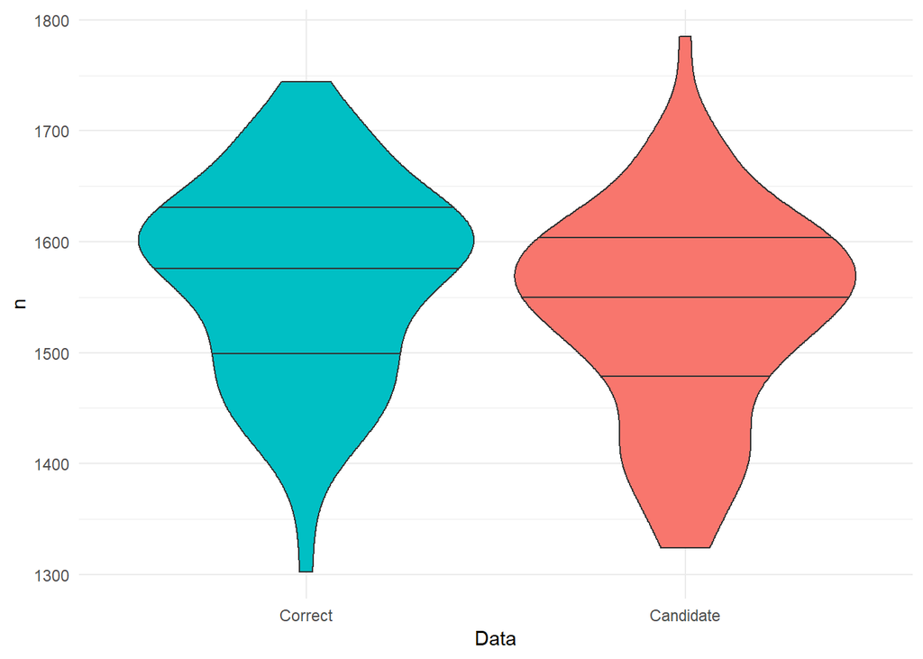

```r
violin_compare(dfs$Date, Date, "n", "inst/extdata/processed/n_Date_arizona.png")
```

#### Mean Latitude

- Differences are on the order of **~1x10-4** on average

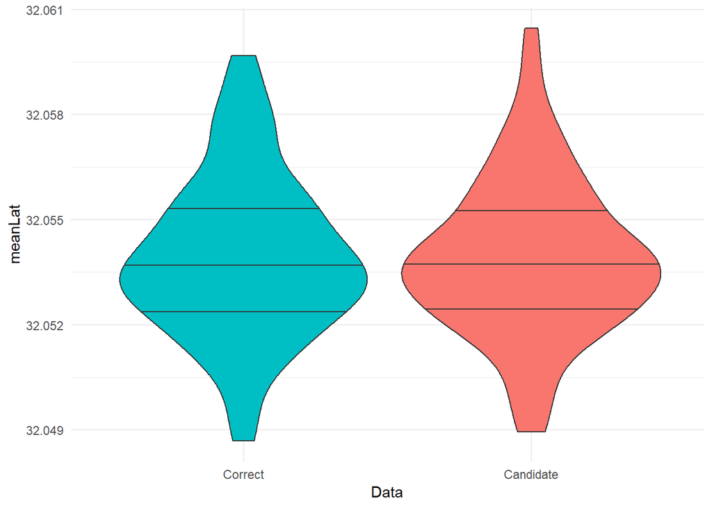

```r
violin_compare(dfs$Date, Date, "meanLat", "inst/extdata/processed/meanLat_Date_arizona.png")
```

#### Mean Longitude

- Differences are on the order of **~1x10-4** on average

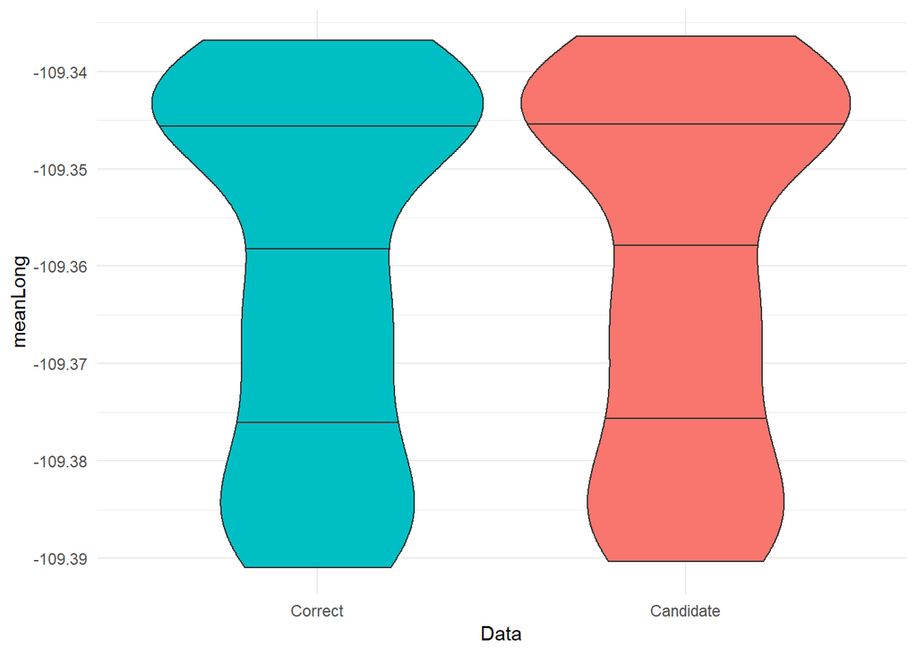

```r
violin_compare(dfs$Date, Date, "meanLong", "inst/extdata/processed/meanLong_Date_arizona.png")
```

#### Mean Distance

- Candidate **underestimates** distance on average by ~3.3 - 8.6

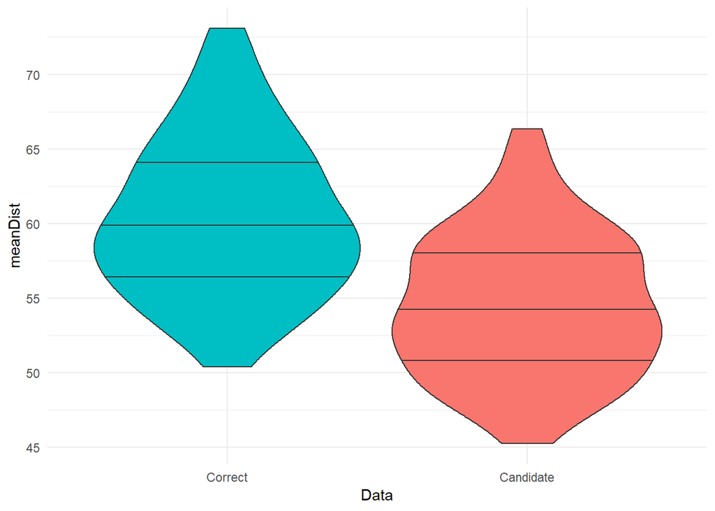

```r
violin_compare(dfs$Date, Date, "meanDist", "inst/extdata/processed/meanDist_Date_arizona.png")
```

#### Mean Course

- Differences are **~ +/- 1** on average**

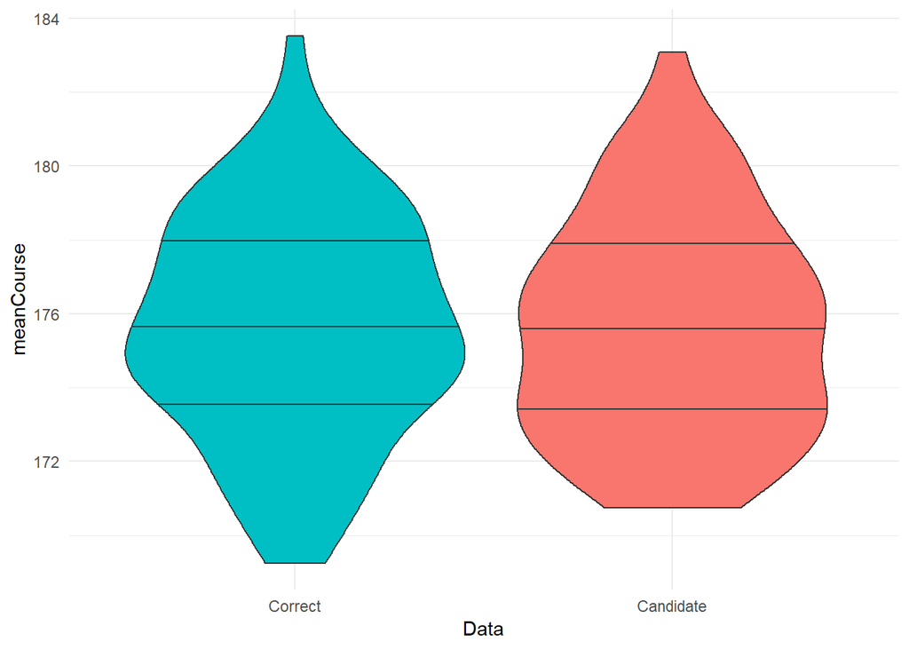

```r
violin_compare(dfs$Date, Date, "meanCourse", "inst/extdata/processed/meanCourse_Date_arizona.png")
```

#### Mean Rate

- Candidate **underestimates** rate on average by ~0.07 - 0.38

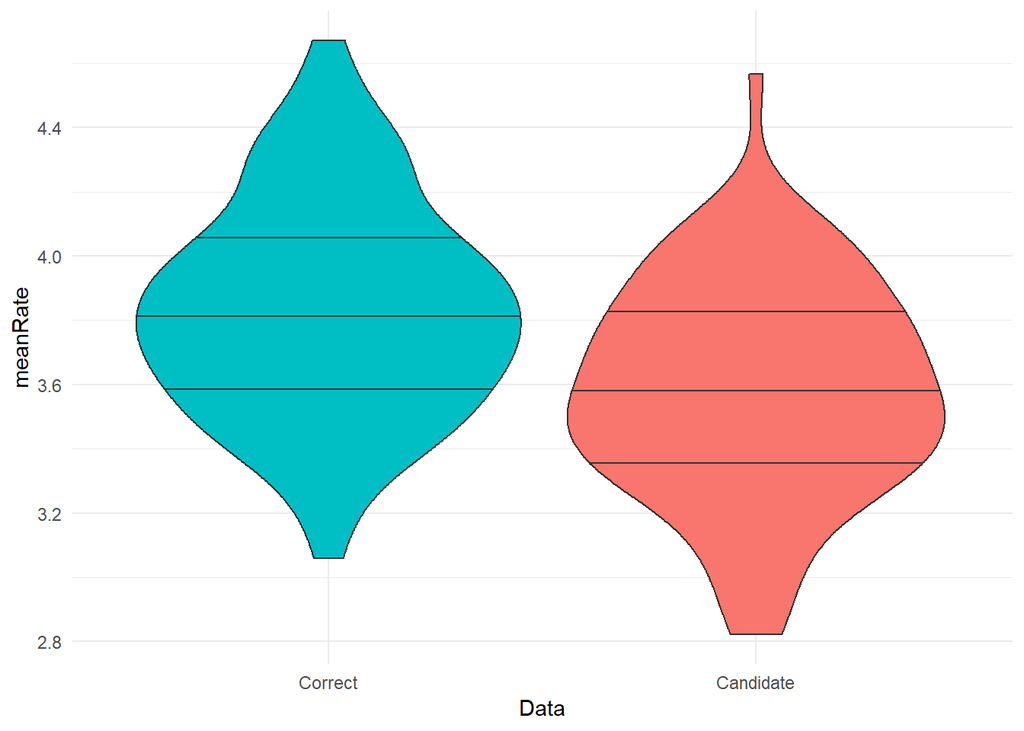

```r
violin_compare(dfs$Date, Date, "meanRate", "inst/extdata/processed/meanRate_Date_arizona.png")
```

#### Mean Elevation

- Candidate **overestimates** elevation on average by ~34 - 10

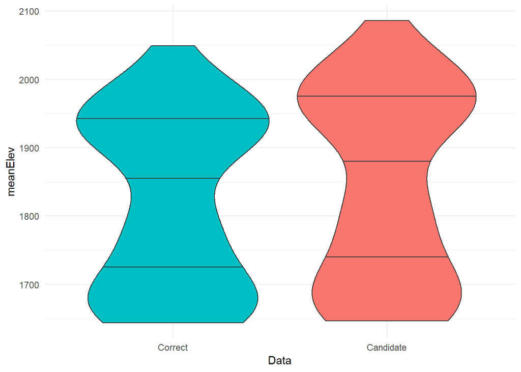

```r
violin_compare(dfs$Date, Date, "meanElev", "inst/extdata/processed/meanElev_Date_arizona.png")
```

### Summary by GPS and Date

- **Close match** between latitude, longitude
- **Underestimates and overestimates** number of rows and course, but difference is a **close match on average**
- **Tends to underestimate** distance, rate **(less variable)**
- **Overestimates** elevation (variability fluctuates)

```r
daily_summary <- compare_summarise_daily(df_correct, df_candidate, "inst/extdata/processed/gps_daily_arizona.csv")

summary(daily_summary)
```

```
##       GPS              Date                 n.x              n.y
##  Min.   : 79.00   Min.   :2018-03-05   Min.   : 30.00   Min.   : 15.00
##  1st Qu.: 83.00   1st Qu.:2018-03-25   1st Qu.: 73.00   1st Qu.: 71.00
##  Median : 88.00   Median :2018-04-14   Median : 85.00   Median : 83.00
##  Mean   : 89.03   Mean   :2018-04-14   Mean   : 84.71   Mean   : 83.12
##  3rd Qu.: 96.00   3rd Qu.:2018-05-05   3rd Qu.: 96.00   3rd Qu.: 95.00
##  Max.   :102.00   Max.   :2018-05-26   Max.   :139.00   Max.   :140.00
##      nDiff           meanLat.x       meanLat.y      meanLatDiff
##  Min.   :-30.000   Min.   :32.04   Min.   :32.04   Min.   :-5.378e-03
##  1st Qu.: -5.000   1st Qu.:32.05   1st Qu.:32.05   1st Qu.:-3.378e-04
##  Median :  2.000   Median :32.05   Median :32.05   Median : 1.940e-07
##  Mean   :  1.593   Mean   :32.05   Mean   :32.05   Mean   : 3.442e-05
##  3rd Qu.:  8.000   3rd Qu.:32.06   3rd Qu.:32.06   3rd Qu.: 3.842e-04
##  Max.   : 34.000   Max.   :32.06   Max.   :32.06   Max.   : 7.039e-03
##     sdLat.x             sdLat.y            sdLatDiff
##  Min.   :0.0002446   Min.   :0.0001562   Min.   :0.0002983
##  1st Qu.:0.0007884   1st Qu.:0.0007403   1st Qu.:0.0011851
##  Median :0.0010929   Median :0.0010421   Median :0.0015786
##  Mean   :0.0014875   Mean   :0.0015180   Mean   :0.0021857
##  3rd Qu.:0.0017537   3rd Qu.:0.0017370   3rd Qu.:0.0024947
##  Max.   :0.0066886   Max.   :0.0095016   Max.   :0.0103872
##    meanLong.x       meanLong.y      meanLongDiff
##  Min.   :-109.4   Min.   :-109.4   Min.   :-5.235e-03
##  1st Qu.:-109.4   1st Qu.:-109.4   1st Qu.:-4.360e-04
##  Median :-109.4   Median :-109.4   Median : 3.109e-05
##  Mean   :-109.4   Mean   :-109.4   Mean   : 8.221e-05
##  3rd Qu.:-109.3   3rd Qu.:-109.3   3rd Qu.: 5.673e-04
##  Max.   :-109.3   Max.   :-109.3   Max.   : 8.173e-03
##     sdLong.x            sdLong.y           sdLongDiff
##  Min.   :0.0002363   Min.   :0.0002844   Min.   :0.0004087
##  1st Qu.:0.0009767   1st Qu.:0.0009033   1st Qu.:0.0014377
##  Median :0.0015406   Median :0.0014263   Median :0.0021700
##  Mean   :0.0022130   Mean   :0.0021840   Mean   :0.0031900
##  3rd Qu.:0.0029920   3rd Qu.:0.0028979   3rd Qu.:0.0044916
##  Max.   :0.0101615   Max.   :0.0148617   Max.   :0.0150650
##    meanDist.x       meanDist.y      meanDistDiff        sdDist.x
##  Min.   : 20.37   Min.   : 21.25   Min.   :-52.163   Min.   :  16.07
##  1st Qu.: 45.79   1st Qu.: 43.16   1st Qu.: -4.020   1st Qu.:  68.42
##  Median : 58.18   Median : 53.35   Median :  3.345   Median :  98.56
##  Mean   : 62.25   Mean   : 55.65   Mean   :  6.599   Mean   : 111.05
```

[output cut: 22 more lines]

```
##  Max.   :9.203   Max.   :9.1633   Max.   : 4.8478   Max.   :19.393
##     sdRate.y         sdRateDiff       meanElev.x     meanElev.y
##  Min.   : 0.7283   Min.   : 1.267   Min.   :1616   Min.   :1615
##  1st Qu.: 3.3453   1st Qu.: 5.557   1st Qu.:1661   1st Qu.:1665
##  Median : 4.9751   Median : 7.787   Median :1824   Median :1853
##  Mean   : 5.2984   Mean   : 8.185   Mean   :1824   Mean   :1847
##  3rd Qu.: 6.6861   3rd Qu.:10.264   3rd Qu.:1955   3rd Qu.:1986
##  Max.   :18.4739   Max.   :26.441   Max.   :2175   Max.   :2210
##   meanElevDiff         sdElev.x         sdElev.y        sdElevDiff
##  Min.   :-119.056   Min.   : 3.314   Min.   :  0.00   Min.   :  4.71
##  1st Qu.: -42.958   1st Qu.:14.341   1st Qu.: 11.73   1st Qu.: 22.59
##  Median : -21.883   Median :20.559   Median : 20.82   Median : 31.55
##  Mean   : -23.680   Mean   :22.813   Mean   : 26.03   Mean   : 37.12
##  3rd Qu.:  -2.862   3rd Qu.:29.191   3rd Qu.: 32.51   3rd Qu.: 46.89
##  Max.   :  72.392   Max.   :97.334   Max.   :116.40   Max.   :118.53
```

#### Number of Observations

- Differs by **~ -5 - 8** rows (correct - candidate) per GPS-date pair

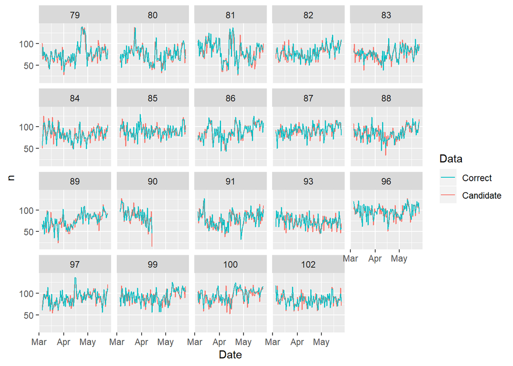

```r
  correct_n <- df_correct %>%
    dplyr::group_by(GPS, Date) %>%
    dplyr::summarise(n = n()) %>%
    dplyr::mutate(Data = "Correct")

  candidate_n <- df_candidate %>%
    dplyr::group_by(GPS, Date) %>%
    dplyr::summarise(n = n()) %>%
    dplyr::mutate(Data = "Candidate")

  plot_data <- dplyr::bind_rows(correct_n, candidate_n)

  ggplot(plot_data, aes(x = Date, y = n, group = Data, color = Data)) +
    geom_line() +
    scale_color_discrete(guide = guide_legend(reverse = T)) +
    facet_wrap(vars(GPS))
```

#### Mean Latitude

- Differences are on the order of **~1x10-4** on average

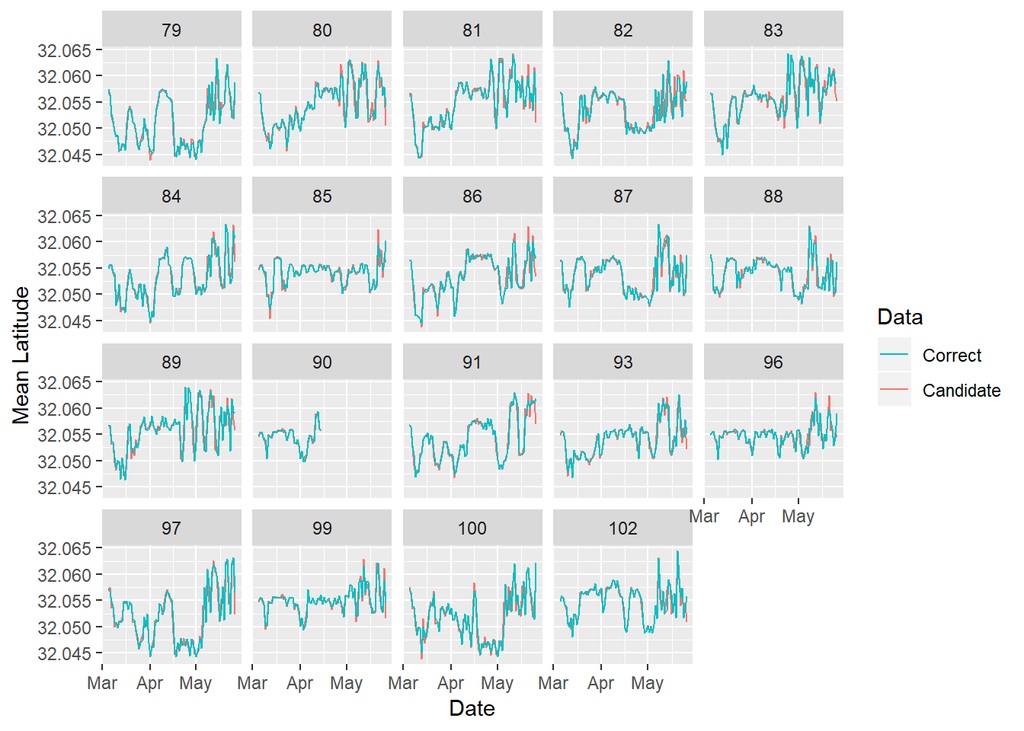

```r
line_compare(df_correct, df_candidate, Latitude, "inst/extdata/processed/meanLat_line_arizona.png")
```

#### Mean Longitude

- Differences are on the order of **~1x10-4** on average

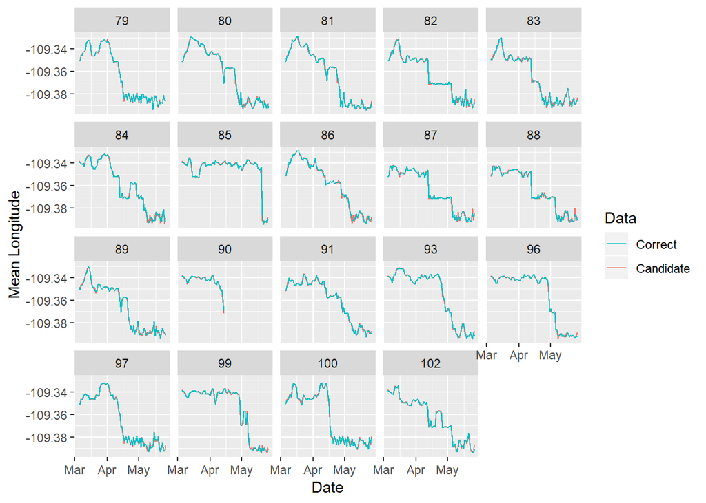

```r
line_compare(df_correct, df_candidate, Longitude, "inst/extdata/processed/meanLong_line_arizona.png")
```

#### Mean Distance

- Differs by **~ -4 - 13.6** on average
- Possible influential points:

```r
knitr::kable(daily_summary %>%
               dplyr::filter((meanDistDiff > quantile(meanDistDiff, 0.75) + 1.5*IQR(meanDistDiff)) |
                             (meanDistDiff < quantile(meanDistDiff, 0.25) - 1.5*IQR(meanDistDiff))) %>%
               dplyr::select(GPS, Date, meanDistDiff))
```

| GPS | Date | meanDistDiff |
| --- | --- | --- |
| 79 | 2018-03-14 | 46.50622 |
| 79 | 2018-03-17 | 61.29862 |
| 79 | 2018-04-01 | 263.63076 |
| 79 | 2018-04-03 | 61.93469 |
| 79 | 2018-04-04 | 43.74295 |
| 79 | 2018-04-09 | 59.89424 |
| 80 | 2018-03-18 | -31.53527 |
| 80 | 2018-04-26 | 47.99431 |
| 80 | 2018-04-27 | 79.00317 |
| 80 | 2018-04-30 | -31.25216 |
| 81 | 2018-04-12 | 63.03677 |
| 81 | 2018-04-27 | 69.87747 |
| 81 | 2018-05-13 | 70.77834 |
| 82 | 2018-03-20 | 48.49101 |
| 82 | 2018-04-05 | 61.33489 |
| 82 | 2018-05-18 | 65.73190 |
| 83 | 2018-04-09 | 80.61171 |
| 84 | 2018-04-13 | 80.19470 |
| 84 | 2018-04-29 | 56.03403 |
| 84 | 2018-05-14 | 41.32933 |
| 84 | 2018-05-25 | 52.61514 |
| 85 | 2018-03-19 | 53.86425 |
| 85 | 2018-03-23 | -35.71490 |
| 85 | 2018-03-24 | 74.06292 |
| 85 | 2018-04-24 | 54.81726 |
| 86 | 2018-03-13 | 38.43498 |
| 86 | 2018-03-16 | 82.54645 |
| 86 | 2018-04-03 | 37.74821 |
| 86 | 2018-04-08 | 58.79321 |
| 86 | 2018-04-19 | 48.10126 |
| 86 | 2018-04-25 | 53.88825 |
| 86 | 2018-04-28 | 46.30017 |
| 86 | 2018-05-01 | 52.06613 |
| 86 | 2018-05-05 | 83.51989 |
| 86 | 2018-05-06 | 36.43814 |
| 87 | 2018-03-20 | 60.07827 |
| 88 | 2018-03-09 | 50.34927 |
| 88 | 2018-03-14 | 36.38896 |
| 88 | 2018-03-26 | 35.91872 |
| 88 | 2018-04-27 | 56.94079 |
| 88 | 2018-05-20 | 46.32597 |
| 88 | 2018-05-24 | 38.58842 |
| 89 | 2018-03-06 | 51.03951 |
| 89 | 2018-03-16 | 112.36814 |
| 89 | 2018-03-25 | 106.96687 |
| 89 | 2018-04-04 | -47.94246 |
| 89 | 2018-04-09 | 69.20489 |
| 90 | 2018-03-13 | 50.37339 |
| 90 | 2018-03-25 | 46.08940 |
| 90 | 2018-04-04 | 62.24764 |
| 90 | 2018-04-06 | 43.95531 |
| 90 | 2018-04-07 | 58.83898 |
| 91 | 2018-03-16 | 44.36741 |
| 91 | 2018-03-31 | 42.45316 |
| 91 | 2018-04-10 | 39.34232 |
| 91 | 2018-04-30 | 70.47699 |
| 93 | 2018-03-09 | 63.21594 |
| 93 | 2018-03-27 | 88.28916 |
| 93 | 2018-04-05 | 122.21871 |
| 93 | 2018-04-27 | 57.56126 |
| 93 | 2018-05-11 | 71.69454 |
| 93 | 2018-05-20 | -41.33224 |
| 96 | 2018-03-21 | 39.16869 |
| 96 | 2018-04-18 | 53.67552 |
| 96 | 2018-04-25 | 37.52088 |
| 97 | 2018-03-05 | 41.04948 |
| 97 | 2018-03-25 | 41.76207 |
| 97 | 2018-04-10 | 70.67029 |
| 99 | 2018-03-17 | 29.32095 |
| 99 | 2018-03-24 | 36.05607 |
| 99 | 2018-04-14 | 45.19689 |
| 99 | 2018-04-15 | -34.24563 |
| 99 | 2018-04-23 | 34.80478 |
| 99 | 2018-04-30 | 29.52122 |
| 99 | 2018-05-06 | 38.57186 |
| 99 | 2018-05-20 | 36.60146 |
| 100 | 2018-04-06 | 32.59426 |
| 100 | 2018-04-18 | 62.64701 |
| 102 | 2018-03-18 | -52.16318 |
| 102 | 2018-03-19 | 42.34197 |

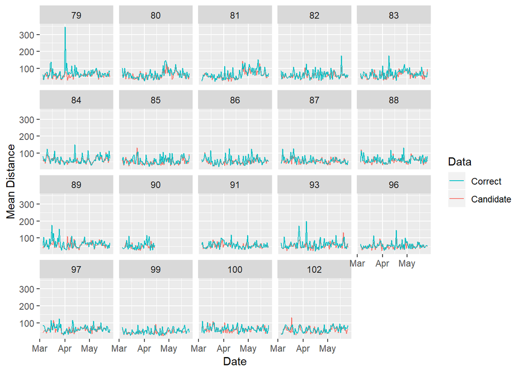

```r
line_compare(df_correct, df_candidate, Distance, "inst/extdata/processed/meanDist_line_arizona.png")
```

#### Mean Course

- Differences are **~ +/- 6** on average
- Possible influential points:

```r
knitr::kable(daily_summary %>%
               dplyr::filter((meanCourseDiff > quantile(meanCourseDiff, 0.75) + 1.5*IQR(meanCourseDiff)) |
                             (meanCourseDiff < quantile(meanCourseDiff, 0.25) - 1.5*IQR(meanCourseDiff))) %>%
               dplyr::select(GPS, Date, meanCourseDiff))
```

| GPS | Date | meanCourseDiff |
| --- | --- | --- |
| 79 | 2018-03-27 | 27.79249 |
| 80 | 2018-03-05 | 22.29286 |
| 81 | 2018-03-16 | -24.30195 |
| 81 | 2018-04-04 | -32.00758 |
| 82 | 2018-04-13 | 29.18653 |
| 83 | 2018-03-18 | 24.43705 |
| 83 | 2018-05-23 | -24.03041 |
| 85 | 2018-03-27 | -23.05000 |
| 85 | 2018-05-08 | 23.16821 |
| 85 | 2018-05-21 | 20.75613 |
| 85 | 2018-05-25 | -20.58324 |
| 88 | 2018-04-19 | -27.38781 |
| 89 | 2018-05-10 | 27.89716 |
| 90 | 2018-04-09 | -21.40869 |
| 93 | 2018-03-16 | -22.35524 |
| 93 | 2018-04-30 | 26.56636 |
| 93 | 2018-05-01 | -25.00906 |
| 93 | 2018-05-25 | 29.11721 |

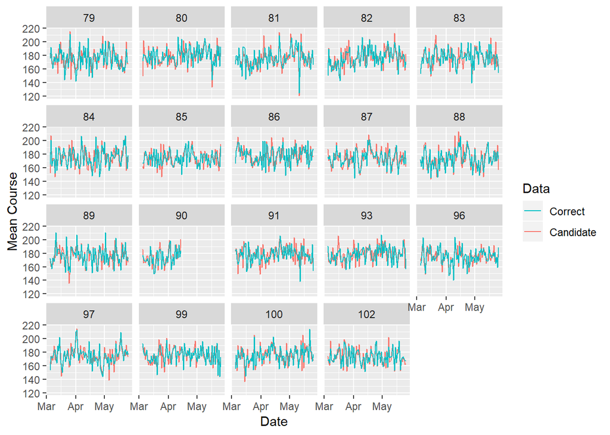

```r
line_compare(df_correct, df_candidate, Course, "inst/extdata/processed/meanCourse_line_arizona.png")
```

#### Mean Rate

- Differs by **~ -0.16 - 0.64** on average
- Possible influential points:

```r
knitr::kable(daily_summary %>%
               dplyr::filter((meanRateDiff > quantile(meanRateDiff, 0.75) + 1.5*IQR(meanRateDiff)) |
                             (meanRateDiff < quantile(meanRateDiff, 0.25) - 1.5*IQR(meanRateDiff))) %>%
               dplyr::select(GPS, Date, meanRateDiff))
```

| GPS | Date | meanRateDiff |
| --- | --- | --- |
| 79 | 2018-03-16 | -1.709507 |
| 79 | 2018-03-17 | 3.376573 |
| 79 | 2018-04-01 | 2.730020 |
| 79 | 2018-04-03 | 3.138497 |
| 79 | 2018-04-09 | 3.381096 |
| 80 | 2018-04-27 | 2.713128 |
| 81 | 2018-05-02 | 1.792577 |
| 81 | 2018-05-05 | -1.481292 |
| 81 | 2018-05-06 | 2.532938 |
| 81 | 2018-05-14 | -2.148923 |
| 81 | 2018-05-15 | 2.113163 |
| 82 | 2018-04-05 | 2.287682 |
| 82 | 2018-04-16 | 2.564553 |
| 82 | 2018-04-29 | 2.087379 |
| 82 | 2018-05-08 | 2.908042 |
| 83 | 2018-04-09 | 4.847753 |
| 83 | 2018-04-17 | 1.634985 |
| 83 | 2018-04-27 | 1.680537 |
| 83 | 2018-04-30 | -1.244959 |
| 83 | 2018-05-03 | -1.187391 |
| 83 | 2018-05-04 | 2.125069 |
| 84 | 2018-05-09 | -1.292196 |
| 85 | 2018-03-24 | 2.012818 |
| 85 | 2018-04-12 | -1.486249 |
| 85 | 2018-05-04 | -2.105280 |
| 85 | 2018-05-05 | 2.613576 |
| 86 | 2018-03-13 | 1.624292 |
| 86 | 2018-03-16 | 2.707401 |
| 86 | 2018-04-08 | 3.511391 |
| 86 | 2018-04-19 | 2.314774 |
| 86 | 2018-05-01 | 3.506092 |
| 86 | 2018-05-02 | -1.909501 |
| 86 | 2018-05-03 | 1.559949 |
| 86 | 2018-05-07 | -2.188092 |
| 86 | 2018-05-08 | 2.919996 |
| 87 | 2018-03-13 | 1.899004 |
| 87 | 2018-03-20 | 1.935789 |
| 88 | 2018-03-09 | 3.371560 |
| 88 | 2018-05-20 | 2.078415 |
| 89 | 2018-03-13 | 3.560207 |
| 90 | 2018-04-04 | 1.946576 |
| 91 | 2018-03-16 | 2.093097 |
| 91 | 2018-03-21 | 1.923572 |
| 91 | 2018-03-28 | 1.808084 |
| 91 | 2018-04-30 | 2.778404 |
| 91 | 2018-05-11 | 1.904241 |
| 93 | 2018-03-09 | 3.237847 |
| 93 | 2018-03-27 | 2.110544 |
| 93 | 2018-04-27 | 3.490205 |
| 93 | 2018-05-09 | -1.290411 |
| 96 | 2018-04-25 | 1.989396 |
| 96 | 2018-04-30 | 2.262743 |
| 99 | 2018-04-09 | 1.949409 |
| 99 | 2018-05-06 | 1.746487 |
| 102 | 2018-03-14 | -1.580438 |
| 102 | 2018-03-18 | -3.664916 |
| 102 | 2018-03-19 | 3.471835 |
| 102 | 2018-05-09 | -2.076034 |
| 102 | 2018-05-10 | 1.840189 |
| 102 | 2018-05-17 | -1.409656 |
| 102 | 2018-05-20 | 1.623800 |
| 102 | 2018-05-26 | 1.663268 |

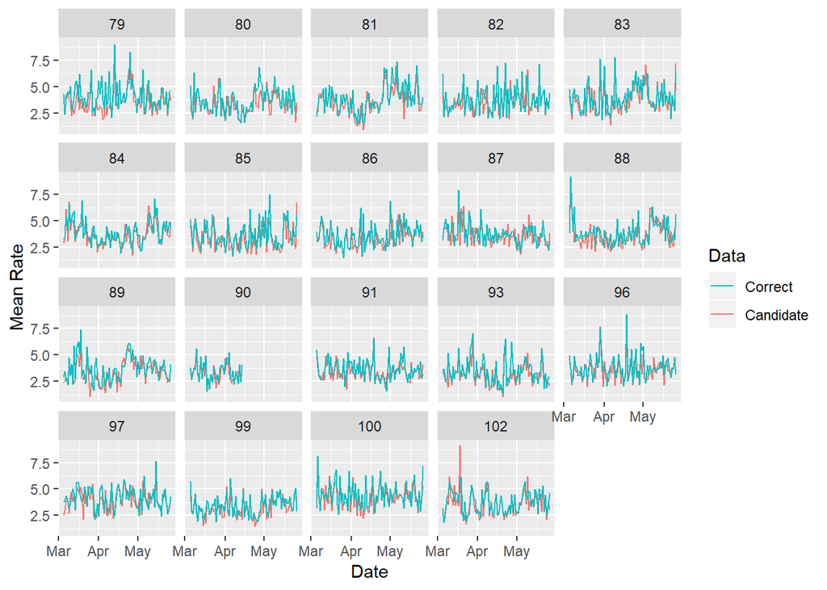

```r
line_compare(df_correct, df_candidate, Rate, "inst/extdata/processed/meanRate_line_arizona.png")
```

#### Mean Elevation

- Candidate **overestimates** elevation on average by ~3 - 43
- Possible influential points:

```r
knitr::kable(daily_summary %>%
               dplyr::filter((meanElevDiff > quantile(meanElevDiff, 0.75) + 1.5*IQR(meanElevDiff)) |
                             (meanElevDiff < quantile(meanElevDiff, 0.25) - 1.5*IQR(meanElevDiff))) %>%
               dplyr::select(GPS, Date, meanElevDiff))
```

| GPS | Date | meanElevDiff |
| --- | --- | --- |
| 79 | 2018-03-09 | -86.82033 |
| 80 | 2018-04-01 | -93.63666 |
| 81 | 2018-04-07 | -114.27025 |
| 85 | 2018-03-21 | 51.66348 |
| 85 | 2018-04-02 | 49.85427 |
| 85 | 2018-04-21 | 55.63923 |
| 85 | 2018-05-19 | 61.60182 |
| 86 | 2018-03-31 | 62.38290 |
| 88 | 2018-05-05 | 72.39221 |
| 89 | 2018-03-13 | -119.05621 |
| 89 | 2018-03-21 | 52.81757 |
| 90 | 2018-03-08 | -84.49011 |
| 90 | 2018-03-13 | -82.34291 |
| 90 | 2018-03-28 | 51.14155 |
| 90 | 2018-03-29 | 32.05445 |
| 90 | 2018-03-31 | 63.44462 |
| 90 | 2018-04-01 | -105.97238 |
| 90 | 2018-04-02 | -86.50771 |
| 90 | 2018-04-08 | 37.90172 |
| 93 | 2018-03-09 | -109.30482 |
| 93 | 2018-03-13 | -100.74797 |
| 93 | 2018-04-19 | 59.16546 |
| 96 | 2018-03-09 | -81.36148 |
| 96 | 2018-03-28 | 48.21411 |
| 96 | 2018-03-30 | -80.23531 |
| 96 | 2018-03-31 | 44.17622 |
| 96 | 2018-04-21 | 59.40962 |
| 96 | 2018-05-05 | 69.24339 |
| 97 | 2018-03-23 | -82.31504 |
| 97 | 2018-03-24 | -88.98815 |
| 97 | 2018-03-29 | -79.78474 |
| 99 | 2018-03-09 | -105.98251 |
| 99 | 2018-03-31 | 64.38890 |
| 99 | 2018-04-01 | -103.10618 |

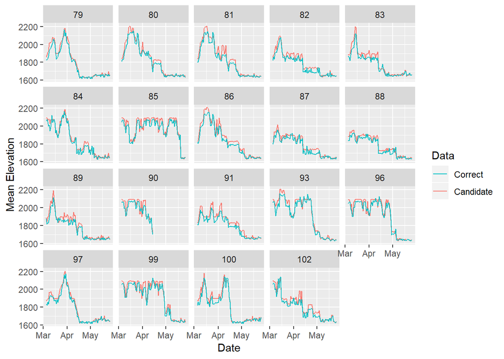

```r
line_compare(df_correct, df_candidate, Elevation, "inst/extdata/processed/meanElev_line_arizona.png")
```